# Practical Machine Learning: Course Project

Yasuyuki Ageishi

February 14, 2015

source: http://groupware.les.inf.puc-rio.br/har

## Overview

- belt
- forearm
- arm
- dumbell
- 6 participant

### Loading and preparing data

```r
train_data_url <- "https://d396qusza40orc.cloudfront.net/predmachlearn/pml-training.csv"

test_data_url <- "https://d396qusza40orc.cloudfront.net/predmachlearn/pml-testing.csv"

## download data
if (!file.exists("./data/pml-training.csv")) {
  download.file(train_data_url, "./data/pml-training.csv", method="curl")
}
if (!file.exists("./data/pml-testing.csv")) {
  download.file(test_data_url, "./data/pml-testing.csv", method="curl")
}

## reading data
train_df <- read.csv("data/pml-training.csv", header=TRUE, row.names="X", na.strings=c("", " ", "NA", "#DIV/0!"))
test_df <- read.csv("data/pml-testing.csv", header=TRUE, row.names="X", na.strings=c(""," ", "NA", "#DIV/0!"))

library(dplyr)
```

|  | rows | cols |
| --- | --- | --- |
| train | 19622 | 159 |
| test | 20 | 159 |

159 features 4 positions (*belt*, *arm*, *dumbbell*, *forearm*) * 38 measurements = 152

```r
sapply(names(train_df)[sapply(names(train_df), function(x) { grepl("forearm",x)})], function(x) { gsub('_forearm', '', x)})
```

```
##            roll_forearm           pitch_forearm             yaw_forearm
##                  "roll"                 "pitch"                   "yaw"
##   kurtosis_roll_forearm  kurtosis_picth_forearm    kurtosis_yaw_forearm
##         "kurtosis_roll"        "kurtosis_picth"          "kurtosis_yaw"
##   skewness_roll_forearm  skewness_pitch_forearm    skewness_yaw_forearm
##         "skewness_roll"        "skewness_pitch"          "skewness_yaw"
##        max_roll_forearm       max_picth_forearm         max_yaw_forearm
##              "max_roll"             "max_picth"               "max_yaw"
##        min_roll_forearm       min_pitch_forearm         min_yaw_forearm
##              "min_roll"             "min_pitch"               "min_yaw"
##  amplitude_roll_forearm amplitude_pitch_forearm   amplitude_yaw_forearm
##        "amplitude_roll"       "amplitude_pitch"         "amplitude_yaw"
##     total_accel_forearm       var_accel_forearm        avg_roll_forearm
##           "total_accel"             "var_accel"              "avg_roll"
##     stddev_roll_forearm        var_roll_forearm       avg_pitch_forearm
##           "stddev_roll"              "var_roll"             "avg_pitch"
##    stddev_pitch_forearm       var_pitch_forearm         avg_yaw_forearm
##          "stddev_pitch"             "var_pitch"               "avg_yaw"
##      stddev_yaw_forearm         var_yaw_forearm         gyros_forearm_x
##            "stddev_yaw"               "var_yaw"               "gyros_x"
##         gyros_forearm_y         gyros_forearm_z         accel_forearm_x
##               "gyros_y"               "gyros_z"               "accel_x"
##         accel_forearm_y         accel_forearm_z        magnet_forearm_x
##               "accel_y"               "accel_z"              "magnet_x"
##        magnet_forearm_y        magnet_forearm_z
##              "magnet_y"              "magnet_z"
```

plus `user_name`, times (`raw_timestamp_part1`, `raw_time_stamp_part_2`, `cvtd_timestamp`, `new_window`, `num_window`) and `classe

### Data cleaning

#### drop columns contains NA values

We drop all variables contain NA values. This process drop 100 variables but we have enough samples (19622 samples) and still have 59 variables. We have to back if we can’t make good model with 59 variables.

```r
train_df <- train_df[, names(train_df)[sapply(names(train_df), function(x) { !any(is.na(train_df[,x])) })]]
test_df <- test_df[, names(test_df)[sapply(names(test_df), function(x) { !any(is.na(test_df[,x]))})]]
dim(train_df); dim(test_df)
```

```
## [1] 19622    59
```

```
## [1] 20 59
```

#### we don’t need cvtd_timestamp since we have raw_timestamp_part_1

```r
train_df <- select(train_df, -(cvtd_timestamp))
test_df <- select(test_df, -(cvtd_timestamp))
```

#### user_name to each user

Create binary variables for each users.

```r
train_df$user_adel <- (train_df$user_name=="adelmo") * 1
train_df$user_carl <- (train_df$user_name=="carlitos") * 1
train_df$user_charles <- (train_df$user_name=="charles") * 1
train_df$user_eurico <- (train_df$user_name=="eurico") * 1
train_df$user_jeremy <- (train_df$user_name=="jeremy") * 1
# all 0 is pedro

test_df$user_adel <- (test_df$user_name=="adelmo") * 1
test_df$user_carl <- (test_df$user_name=="carlitos") * 1
test_df$user_charles <- (test_df$user_name=="charles") * 1
test_df$user_eurico <- (test_df$user_name=="eurico") * 1
test_df$user_jeremy <- (test_df$user_name=="jeremy") * 1
```

### Exploratory analysis

#### Correlation of each variables

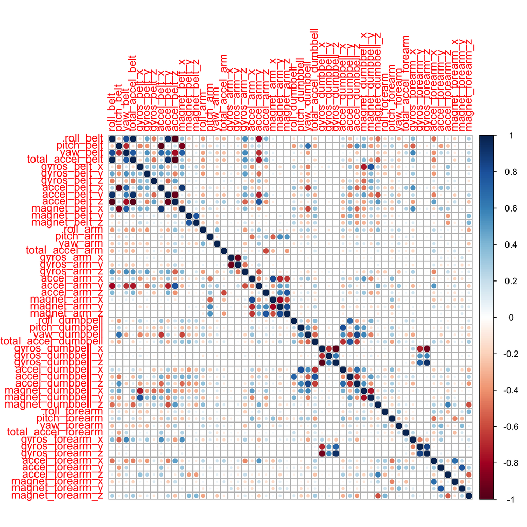

```r
library(corrplot)
corrplot(cor(select(train_df, (roll_belt:magnet_forearm_z))))
```

#### Variables are very vary for each users

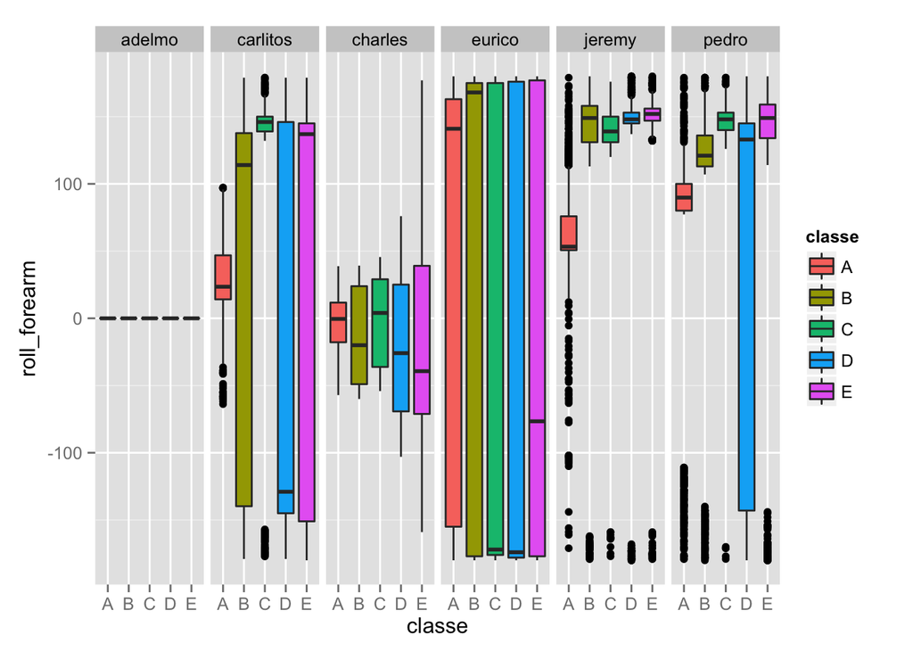

```r
library(ggplot2)
g <- ggplot(train_df, aes(classe, roll_forearm))
p <- g + geom_boxplot(aes(fill=classe)) + facet_grid(. ~ user_name)
p
```

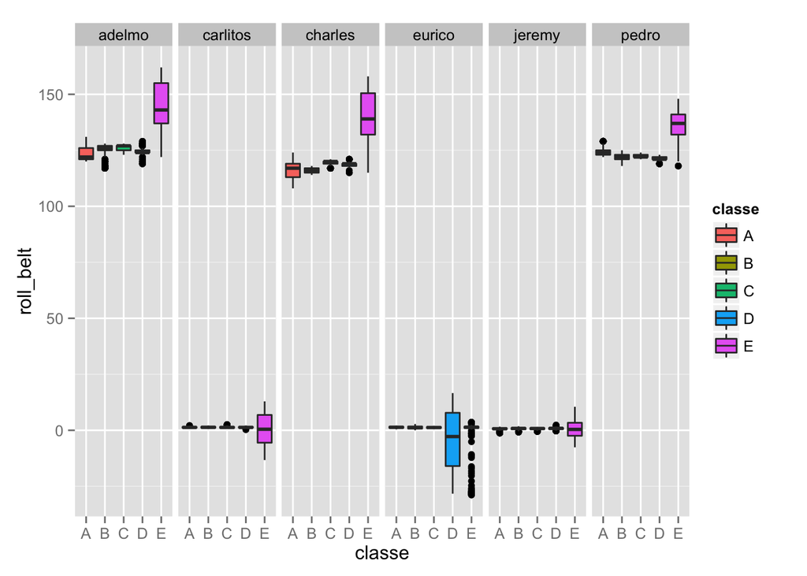

```r
g <- ggplot(train_df, aes(classe, roll_belt))
p <- g + geom_boxplot(aes(fill=classe)) + facet_grid(. ~ user_name)
p
```

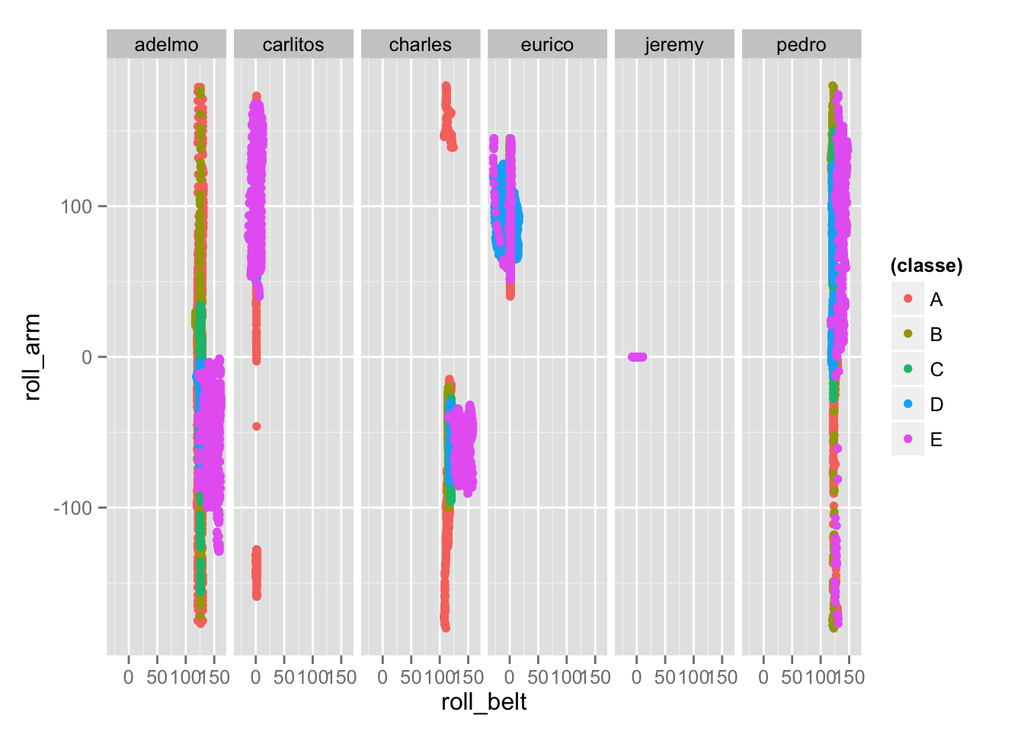

```r
g <- ggplot(train_df, aes(roll_belt, roll_arm))
p <- g + geom_point(aes(colour=(classe))) + facet_grid(. ~ user_name)
p
```

## Training

### Prepare for parallel backend

```r
library(doMC)
registerDoMC(cores=2) # this is setting for my pc with dual core cpu
```

### Split data into training set and testing set

```r
library(caret)
set.seed(999)
inTrain <- createDataPartition(y=train_df$classe, p=.1, list=FALSE)
training <- train_df[inTrain,];testing <- train_df[-inTrain,]
```

### Simple tree model

```r
# this takes a quite while
set.seed(123)
system.time(modFit <- train(classe ~., method='rpart', data=training))
```

```
##    user  system elapsed
##   5.608   0.327   6.442
```

```r
confusionMatrix(predict(modFit, training), training$classe)
```

```
## Confusion Matrix and Statistics
##
##           Reference
## Prediction   A   B   C   D   E
##          A 509 141 152 142  40
##          B  42 196  24  80  55
##          C   5  43 167 100 100
##          D   0   0   0   0   0
##          E   2   0   0   0 166
##
## Overall Statistics
##
##                Accuracy : 0.5285
##                  95% CI : (0.5062, 0.5508)
##     No Information Rate : 0.2841
##     P-Value [Acc > NIR] : < 2.2e-16
##
##                   Kappa : 0.3844
##  Mcnemar's Test P-Value : NA
##
## Statistics by Class:
##
##                      Class: A Class: B Class: C Class: D Class: E
## Sensitivity            0.9122   0.5158  0.48688    0.000  0.45983
## Specificity            0.6622   0.8731  0.84701    1.000  0.99875
## Pos Pred Value         0.5173   0.4937  0.40241      NaN  0.98810
## Neg Pred Value         0.9500   0.8826  0.88638    0.836  0.89143
## Prevalence             0.2841   0.1935  0.17464    0.164  0.18381
## Detection Rate         0.2592   0.0998  0.08503    0.000  0.08452
## Detection Prevalence   0.5010   0.2021  0.21130    0.000  0.08554
## Balanced Accuracy      0.7872   0.6944  0.66694    0.500  0.72929
```

```r
confusionMatrix(predict(modFit, testing), testing$classe)
```

```
## Confusion Matrix and Statistics
##
##           Reference
## Prediction    A    B    C    D    E
##          A 4531 1394 1411 1289  450
##          B  435 1582  269  714  450
##          C   44  441 1399  891  881
##          D    0    0    0    0    0
##          E   12    0    0    0 1465
##
## Overall Statistics
##
##                Accuracy : 0.5084
##                  95% CI : (0.501, 0.5158)
##     No Information Rate : 0.2844
##     P-Value [Acc > NIR] : < 2.2e-16
##
##                   Kappa : 0.357
##  Mcnemar's Test P-Value : NA
##
## Statistics by Class:
##
##                      Class: A Class: B Class: C Class: D Class: E
## Sensitivity            0.9022  0.46298  0.45437   0.0000  0.45132
## Specificity            0.6404  0.86883  0.84519   1.0000  0.99917
## Pos Pred Value         0.4993  0.45855  0.38266      NaN  0.99188
## Neg Pred Value         0.9428  0.87085  0.88002   0.8361  0.88993
## Prevalence             0.2844  0.19351  0.17437   0.1639  0.18383
## Detection Rate         0.2566  0.08959  0.07923   0.0000  0.08297
## Detection Prevalence   0.5139  0.19538  0.20704   0.0000  0.08364
## Balanced Accuracy      0.7713  0.66590  0.64978   0.5000  0.72525
```

### Random forest

Basic simple random forest model

```r
set.seed(123)
system.time(modRf <- train(classe ~., method='rf', data=training))
```

```
##    user  system elapsed
## 242.859   2.654 252.280
```

```r
confusionMatrix(predict(modRf, training), training$classe)
```

```
## Confusion Matrix and Statistics
##
##           Reference
## Prediction   A   B   C   D   E
##          A 558   0   0   0   0
##          B   0 380   0   0   0
##          C   0   0 343   0   0
##          D   0   0   0 322   0
##          E   0   0   0   0 361
##
## Overall Statistics
##
##                Accuracy : 1
##                  95% CI : (0.9981, 1)
##     No Information Rate : 0.2841
##     P-Value [Acc > NIR] : < 2.2e-16
##
##                   Kappa : 1
##  Mcnemar's Test P-Value : NA
##
## Statistics by Class:
##
##                      Class: A Class: B Class: C Class: D Class: E
## Sensitivity            1.0000   1.0000   1.0000    1.000   1.0000
## Specificity            1.0000   1.0000   1.0000    1.000   1.0000
## Pos Pred Value         1.0000   1.0000   1.0000    1.000   1.0000
## Neg Pred Value         1.0000   1.0000   1.0000    1.000   1.0000
## Prevalence             0.2841   0.1935   0.1746    0.164   0.1838
## Detection Rate         0.2841   0.1935   0.1746    0.164   0.1838
## Detection Prevalence   0.2841   0.1935   0.1746    0.164   0.1838
## Balanced Accuracy      1.0000   1.0000   1.0000    1.000   1.0000
```

```r
confusionMatrix(predict(modRf, testing), testing$classe)
```

```
## Confusion Matrix and Statistics
##
##           Reference
## Prediction    A    B    C    D    E
##          A 5022   78    0    0    0
##          B    0 3299   60    0    3
##          C    0   40 3002   48    4
##          D    0    0   17 2842   47
##          E    0    0    0    4 3192
##
## Overall Statistics
##
##                Accuracy : 0.983
##                  95% CI : (0.9809, 0.9848)
##     No Information Rate : 0.2844
##     P-Value [Acc > NIR] : < 2.2e-16
##
##                   Kappa : 0.9784
##  Mcnemar's Test P-Value : NA
##
## Statistics by Class:
##
##                      Class: A Class: B Class: C Class: D Class: E
## Sensitivity            1.0000   0.9655   0.9750   0.9820   0.9834
## Specificity            0.9938   0.9956   0.9937   0.9957   0.9997
## Pos Pred Value         0.9847   0.9813   0.9703   0.9780   0.9987
## Neg Pred Value         1.0000   0.9917   0.9947   0.9965   0.9963
## Prevalence             0.2844   0.1935   0.1744   0.1639   0.1838
## Detection Rate         0.2844   0.1868   0.1700   0.1609   0.1808
## Detection Prevalence   0.2888   0.1904   0.1752   0.1646   0.1810
## Balanced Accuracy      0.9969   0.9805   0.9843   0.9888   0.9915
```

### Random forest enhanced with variable selection

We will try to enhance our random forest model by selecting variables. To select variables we use variable importance from random forestmodel we just created.

```r
vi <- varImp(modRf)
vi
```

```
## rf variable importance
##
##   only 20 most important variables shown (out of 66)
##
##                      Overall
## raw_timestamp_part_1 100.000
## roll_belt             58.695
## num_window            57.494
## pitch_forearm         37.684
## magnet_dumbbell_z     30.221
## magnet_dumbbell_y     23.536
## yaw_belt              21.206
## roll_forearm          20.706
## pitch_belt            16.816
## roll_dumbbell         14.277
## magnet_dumbbell_x     12.254
## accel_forearm_x       10.624
## total_accel_dumbbell   9.757
## accel_dumbbell_y       9.648
## magnet_belt_y          9.353
## accel_belt_z           8.863
## magnet_belt_z          8.617
## accel_dumbbell_z       8.198
## roll_arm               7.440
## magnet_arm_x           6.588
```

From variable importance, we choose `raw_timestamp_part_1`, `roll_belt` and `pitch_forearm`.

```r
set.seed(123)
system.time(modRf2 <- train(classe ~ raw_timestamp_part_1 + roll_belt + pitch_forearm, method='rf',
                           data=training))
```

[output not shown]

```r
confusionMatrix(predict(modRf2, training), training$classe)
```

```
## Confusion Matrix and Statistics
##
##           Reference
## Prediction   A   B   C   D   E
##          A 558   0   0   0   0
##          B   0 380   0   0   0
##          C   0   0 343   0   0
##          D   0   0   0 322   0
##          E   0   0   0   0 361
##
## Overall Statistics
##
##                Accuracy : 1
##                  95% CI : (0.9981, 1)
##     No Information Rate : 0.2841
##     P-Value [Acc > NIR] : < 2.2e-16
##
##                   Kappa : 1
##  Mcnemar's Test P-Value : NA
##
## Statistics by Class:
##
##                      Class: A Class: B Class: C Class: D Class: E
## Sensitivity            1.0000   1.0000   1.0000    1.000   1.0000
## Specificity            1.0000   1.0000   1.0000    1.000   1.0000
## Pos Pred Value         1.0000   1.0000   1.0000    1.000   1.0000
## Neg Pred Value         1.0000   1.0000   1.0000    1.000   1.0000
## Prevalence             0.2841   0.1935   0.1746    0.164   0.1838
## Detection Rate         0.2841   0.1935   0.1746    0.164   0.1838
## Detection Prevalence   0.2841   0.1935   0.1746    0.164   0.1838
## Balanced Accuracy      1.0000   1.0000   1.0000    1.000   1.0000
```

```r
confusionMatrix(predict(modRf2, testing), testing$classe)
```

```
## Confusion Matrix and Statistics
##
##           Reference
## Prediction    A    B    C    D    E
##          A 5010   43    0    0    0
##          B   12 3364   26    0    0
##          C    0   10 3035   23    0
##          D    0    0   18 2859   17
##          E    0    0    0   12 3229
##
## Overall Statistics
##
##                Accuracy : 0.9909
##                  95% CI : (0.9894, 0.9922)
##     No Information Rate : 0.2844
##     P-Value [Acc > NIR] : < 2.2e-16
##
##                   Kappa : 0.9885
##  Mcnemar's Test P-Value : NA
##
## Statistics by Class:
##
##                      Class: A Class: B Class: C Class: D Class: E
## Sensitivity            0.9976   0.9845   0.9857   0.9879   0.9948
## Specificity            0.9966   0.9973   0.9977   0.9976   0.9992
## Pos Pred Value         0.9915   0.9888   0.9892   0.9879   0.9963
## Neg Pred Value         0.9990   0.9963   0.9970   0.9976   0.9988
## Prevalence             0.2844   0.1935   0.1744   0.1639   0.1838
## Detection Rate         0.2837   0.1905   0.1719   0.1619   0.1829
## Detection Prevalence   0.2862   0.1927   0.1737   0.1639   0.1835
## Balanced Accuracy      0.9971   0.9909   0.9917   0.9928   0.9970
```

#### Adding users variables to enhanced random forest

Let’s try to add users variable since we know that variables are very vary from user to user.

```r
set.seed(123)
system.time(modRf3 <- train(classe ~ raw_timestamp_part_1 + roll_belt + pitch_forearm + user_adel + user_carl + user_charles + user_eurico + user_jeremy, method='rf',
                           data=training))
```

```
##    user  system elapsed
##  61.290   2.592  43.390
```

```r
confusionMatrix(predict(modRf3, training), training$classe)
```

```
## Confusion Matrix and Statistics
##
##           Reference
## Prediction   A   B   C   D   E
##          A 558   0   0   0   0
##          B   0 380   0   0   0
##          C   0   0 343   0   0
##          D   0   0   0 322   0
##          E   0   0   0   0 361
##
## Overall Statistics
##
##                Accuracy : 1
##                  95% CI : (0.9981, 1)
##     No Information Rate : 0.2841
##     P-Value [Acc > NIR] : < 2.2e-16
##
##                   Kappa : 1
##  Mcnemar's Test P-Value : NA
##
## Statistics by Class:
##
##                      Class: A Class: B Class: C Class: D Class: E
## Sensitivity            1.0000   1.0000   1.0000    1.000   1.0000
## Specificity            1.0000   1.0000   1.0000    1.000   1.0000
## Pos Pred Value         1.0000   1.0000   1.0000    1.000   1.0000
## Neg Pred Value         1.0000   1.0000   1.0000    1.000   1.0000
## Prevalence             0.2841   0.1935   0.1746    0.164   0.1838
## Detection Rate         0.2841   0.1935   0.1746    0.164   0.1838
## Detection Prevalence   0.2841   0.1935   0.1746    0.164   0.1838
## Balanced Accuracy      1.0000   1.0000   1.0000    1.000   1.0000
```

```r
confusionMatrix(predict(modRf3, testing), testing$classe)
```

```
## Confusion Matrix and Statistics
##
##           Reference
## Prediction    A    B    C    D    E
##          A 5010   43    0    0    0
##          B   12 3364   26    0    0
##          C    0   10 3034   22    0
##          D    0    0   19 2860   19
##          E    0    0    0   12 3227
##
## Overall Statistics
##
##                Accuracy : 0.9908
##                  95% CI : (0.9892, 0.9921)
##     No Information Rate : 0.2844
##     P-Value [Acc > NIR] : < 2.2e-16
##
##                   Kappa : 0.9883
##  Mcnemar's Test P-Value : NA
##
## Statistics by Class:
##
##                      Class: A Class: B Class: C Class: D Class: E
## Sensitivity            0.9976   0.9845   0.9854   0.9883   0.9941
## Specificity            0.9966   0.9973   0.9978   0.9974   0.9992
## Pos Pred Value         0.9915   0.9888   0.9896   0.9869   0.9963
## Neg Pred Value         0.9990   0.9963   0.9969   0.9977   0.9987
## Prevalence             0.2844   0.1935   0.1744   0.1639   0.1838
## Detection Rate         0.2837   0.1905   0.1718   0.1620   0.1828
## Detection Prevalence   0.2862   0.1927   0.1736   0.1641   0.1834
## Balanced Accuracy      0.9971   0.9909   0.9916   0.9928   0.9967
```

### GBM

```r
set.seed(123)
system.time(modGbm <- train(classe ~., method='gbm', data=training, verbose=FALSE))
confusionMatrix(predict(modGbm, training), na.omit(training)$classe)
confusionMatrix(predict(modGbm, testing), na.omit(testing)$classe)
```

[output not shown]

### Fine tuning

#### Train control

```r
fitControl <- trainControl(## 10-fold CV
                           method="repeatedCV",
                           number=10,
                           ## repeated 10 times
                           repeats=3)
set.seed(123)
system.time(modRf2 <- train(classe ~., data=training, method='rf', trControl=fitControl))
modRf2
confusionMatrix(predict(modRf2, training), na.omit(training)$classe)
confusionMatrix(predict(modRf2, testing), na.omit(testing)$classe)

set.seed(123)
system.time(modGbm2 <- train(classe ~., data=training, method='gbm', verbose=FALSE, trControl=fitControl))
modGbm2
confusionMatrix(predict(modGbm2, training), na.omit(training)$classe)
confusionMatrix(predict(modGbm2, testing), na.omit(testing)$classe)
```

[output not shown]

### Selecting variable in random forest

```r
rfFitControl <- trainControl(## 10-fold CV
                           method="repeatedCV",
                           number=10,
                           repeats=5)

set.seed(123)
#    user  system elapsed
# 235.402   3.346 242.222

system.time(modRf2 <- train(classe ~., method='rf',
                            data=training,
                            importance=TRUE,
                            trControl=rfFitControl))
vi <- varImp(modRf2)

set.seed(123)
system.time(modRf3 <- train(classe ~ stddev_roll_belt + avg_roll_dumbbell + raw_timestamp_part_1 + user_adel + user_carl + user_charles + user_eurico + user_jeremy, method='rf',
                            data=training,
                            importance=TRUE,
                            trControl=rfFitControl))

confusionMatrix(predict(modRf3, na.omit(testing)), na.omit(testing)$classe)
```

[output not shown]

### Selecting variables in GBM

```r
set.seed(123)
#    user  system elapsed
# 235.402   3.346 242.222


vi <- varImp(modGbm2)
vi

set.seed(123)
system.time(modGbmS <- train(classe ~ avg_roll_dumbbell + stddev_roll_belt +  raw_timestamp_part_1 + user_adel + user_carl + user_charles + user_eurico + user_jeremy, method='gbm',
                            data=training,
                            verbose=FALSE,
                            trControl=rfFitControl))

confusionMatrix(predict(modGbmS, na.omit(testing)), na.omit(testing)$classe)
```

[output not shown]

#### Enhance GBM with grid

http://topepo.github.io/caret/training.html

```r
gbmGrid <- expand.grid(interaction.depth = c(3,5,7),
                       n.trees = (1:5) * 50,
                       shrinkage = .1)

set.seed(123)

# gbmGrid <- expand.grid(interaction.depth = c(1,5,9),
                        # n.trees = (1:30) * 50,
                        # shrinkage = .1)
#     user   system  elapsed
# 2909.468    9.007 2930.066
set.seed(123)
system.time(modGbmS_enh <- train(classe ~ avg_roll_dumbbell + stddev_roll_belt +  raw_timestamp_part_1 + user_adel + user_carl + user_charles + user_eurico + user_jeremy, method='gbm',
                            data=training,
                            verbose=FALSE,
                            trControl=rfFitControl,
                            tuneGrid=gbmGrid))
modGbmS_enh
ggplot(modGbmS_enh)
confusionMatrix(predict(modGbmS_enh, testing), na.omit(testing)$classe)
```

[output not shown]